# SVM（分類）

目次

- Data Preprocessing
  - 1. データを読み込む
  - 1. データ構造を確認する
  - 1. 目的変数・説明変数間の分布を確認する
  - 1. 説明変数間の多重共線性を確認する
  - 1. データの欠損に対処する
  - 1. データの尺度を正規化する
  - 1. 目的変数のデータ分布の偏りに対処する
  - 1. 質的データを変換する
- モデル生成・評価・予測
  - モデル生成
  - モデル評価
  - モデル予測

## Data Preprocessing

### 0. データを読み込む

```python
import pandas as pd
import numpy as np

import matplotlib.pyplot as plt
import seaborn as sns
%matplotlib inline
sns.set()

from sklearn.model_selection import GridSearchCV
from sklearn.preprocessing import StandardScaler
from sklearn.svm import SVC

from sklearn.model_selection import train_test_split

from sklearn.metrics import confusion_matrix
from sklearn.metrics import accuracy_score
from sklearn.metrics import precision_recall_curve
from sklearn.metrics import roc_curve, auc

from sklearn.metrics import precision_score
from sklearn.metrics import recall_score
from sklearn.metrics import f1_score

import warnings
warnings.filterwarnings('ignore')
```

```python
df = pd.read_csv('data_banknote_authentication.csv', names=["X1","X2","X3","X4","y"])
# Dataset URL:https://archive.ics.uci.edu/ml/datasets/banknote+authentication
```

### 1. データ構造を確認する

```python
df.info(max_cols=None)
```

```
<class 'pandas.core.frame.DataFrame'>
RangeIndex: 1372 entries, 0 to 1371
Data columns (total 5 columns):
X1    1372 non-null float64
X2    1372 non-null float64
X3    1372 non-null float64
X4    1372 non-null float64
y     1372 non-null int64
dtypes: float64(4), int64(1)
memory usage: 53.7 KB
```

変数一覧:

- X1 ウェーブレット変換画像の分散
- X2 ウェーブレット変換画像の歪度
- X3 ウェーブレット変換画像の尖度
- X4 画像エントロピー
- y 偽札判定（偽札:1 非偽札:0）＝目的変数

#### 欠損値の有無を確認

```python
df.isnull().sum()
```

```
X1    0
X2    0
X3    0
X4    0
y     0
dtype: int64
```

欠損値は無し。

### 2. 目的変数・説明変数間の分布を確認する

```python
df.head()
```

|  | X1 | X2 | X3 | X4 | y |
| --- | --- | --- | --- | --- | --- |
| 0 | 3.62160 | 8.6661 | -2.8073 | -0.44699 | 0 |
| 1 | 4.54590 | 8.1674 | -2.4586 | -1.46210 | 0 |
| 2 | 3.86600 | -2.6383 | 1.9242 | 0.10645 | 0 |
| 3 | 3.45660 | 9.5228 | -4.0112 | -3.59440 | 0 |
| 4 | 0.32924 | -4.4552 | 4.5718 | -0.98880 | 0 |

#### 基本統計量の確認

```python
df[['X1','X2','X3','X4']].describe()
```

|  | X1 | X2 | X3 | X4 |
| --- | --- | --- | --- | --- |
| count | 1372.000000 | 1372.000000 | 1372.000000 | 1372.000000 |
| mean | 0.433735 | 1.922353 | 1.397627 | -1.191657 |
| std | 2.842763 | 5.869047 | 4.310030 | 2.101013 |
| min | -7.042100 | -13.773100 | -5.286100 | -8.548200 |
| 25% | -1.773000 | -1.708200 | -1.574975 | -2.413450 |
| 50% | 0.496180 | 2.319650 | 0.616630 | -0.586650 |
| 75% | 2.821475 | 6.814625 | 3.179250 | 0.394810 |
| max | 6.824800 | 12.951600 | 17.927400 | 2.449500 |

#### 説明変数の分布（多重共線性の確認とその対処も行う）

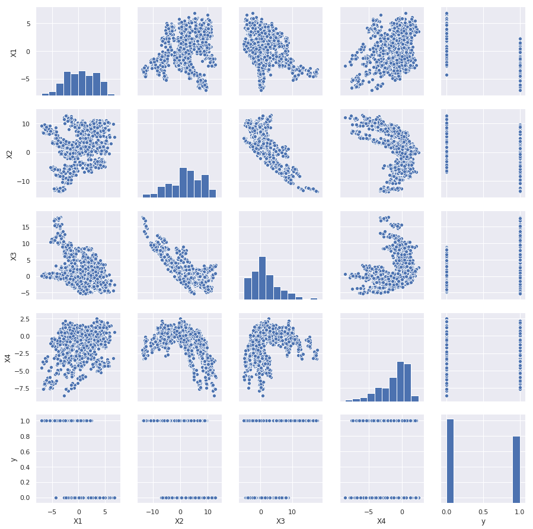

```python
sns.pairplot(df, kind='scatter', diag_kind='hist')
```

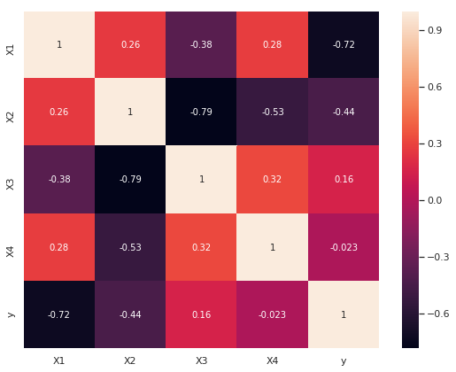

```python
plt.figure(figsize=(9, 7))
sns.heatmap(df.corr(),annot=True)
```

- 一般論として、説明変数間の相関係数の絶対値が0.7以上の場合、強い相関、すなわち多重共線性が認められる。
- しかし、強い相関のある X2, X3の散布図を見ると非楕円形であり、相関係数の高さは、X2,X3以外の因子が存在するかもしれない。
- したがって、説明変数の削除は行わない。

#### 目的変数の分布

```
y
0    762
1    610
dtype: int64
```

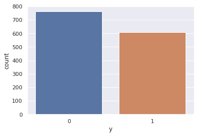

```python
sns.countplot(x=df['y'], data=df)
df.groupby('y').size()
```

顕著な偏りは無いと見なし、補正は行わない。

### 3. 説明変数間の多重共線性を確認する

既に述べたとおり、多重共線性は認められるが説明変数の削除は行わない。

### 4. データの欠損に対処する

欠損は無いため対処不要

### 5. データの尺度を正規化する

#### 正規化方法を検討するため現時点の説明変数の分布を表示

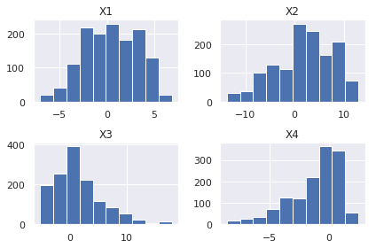

```python
fig = plt.figure()
ax1 = fig.add_subplot(221)
ax2 = fig.add_subplot(222)
ax3 = fig.add_subplot(223)
ax4 = fig.add_subplot(224)

ax1.hist(df['X1'].values)
ax2.hist(df['X2'].values)
ax3.hist(df['X3'].values)
ax4.hist(df['X4'].values)

ax1.set_title('X1')
ax2.set_title('X2')
ax3.set_title('X3')
ax4.set_title('X4')

fig.tight_layout()
plt.show()
```

説明変数は全て標準正規分布で正規化する。

```python
X_df = df[['X1','X2','X3', 'X4']]
y_df = df['y']

df_np = StandardScaler().fit_transform(X_df)
X_df_std = pd.DataFrame(df_np, columns=['X1','X2','X3', 'X4'])

df_std = X_df_std.join(y_df)
df_std.head()
```

|  | X1 | X2 | X3 | X4 | y |
| --- | --- | --- | --- | --- | --- |
| 0 | 1.121806 | 1.149455 | -0.975970 | 0.354561 | 0 |
| 1 | 1.447066 | 1.064453 | -0.895036 | -0.128767 | 0 |
| 2 | 1.207810 | -0.777352 | 0.122218 | 0.618073 | 0 |
| 3 | 1.063742 | 1.295478 | -1.255397 | -1.144029 | 0 |
| 4 | -0.036772 | -1.087038 | 0.736730 | 0.096587 | 0 |

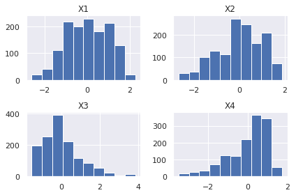

```python
fig = plt.figure()
ax1 = fig.add_subplot(221)
ax2 = fig.add_subplot(222)
ax3 = fig.add_subplot(223)
ax4 = fig.add_subplot(224)

ax1.hist(df_std['X1'].values)
ax2.hist(df_std['X2'].values)
ax3.hist(df_std['X3'].values)
ax4.hist(df_std['X4'].values)

ax1.set_title('X1')
ax2.set_title('X2')
ax3.set_title('X3')
ax4.set_title('X4')

fig.tight_layout()
plt.show()
```

### 6. 目的変数のデータ分布の偏りに対処する

目的変数の分布で述べたとおり偏りは無いとみなし対処不要。

### 7. 質的データを変換する

説明変数に質的データは無いため対処不要。

## モデル生成・評価・予測

### モデル生成

#### 学習データと評価データに分割する

```python
X_train, X_test, y_train, y_test = train_test_split(
    X_df_std,
    y_df,
    test_size = 300,
    random_state = 0
    )
```

```python
print(X_train.shape, X_test.shape, y_train.shape, y_test.shape)
```

```
(1072, 4) (300, 4) (1072,) (300,)
```

#### 交差検証とグリッドサーチを同時に実行する

```python
parameters = { 'C':np.logspace(-4,4,20), 'gamma':np.logspace(-4,4,20)}
grid_search = GridSearchCV(
                    SVC(kernel='rbf', probability=True),
                    parameters,
                    cv = 2
                )
grid_search.fit(X_train, y_train)
```

```
GridSearchCV(cv=2, error_score='raise',
       estimator=SVC(C=1.0, cache_size=200, class_weight=None, coef0=0.0,
  decision_function_shape='ovr', degree=3, gamma='auto', kernel='rbf',
  max_iter=-1, probability=True, random_state=None, shrinking=True,
  tol=0.001, verbose=False),
       fit_params=None, iid=True, n_jobs=1,
       param_grid={'C': array([1.00000e-04, 2.63665e-04, 6.95193e-04, 1.83298e-03, 4.83293e-03,
       1.27427e-02, 3.35982e-02, 8.85867e-02, 2.33572e-01, 6.15848e-01,
       1.62378e+00, 4.28133e+00, 1.12884e+01, 2.97635e+01, 7.84760e+01,
       2.06914e+02, 5.45559e+02, 1.43845e+03, 3.79269e+03, 1.00000e... 2.97635e+01, 7.84760e+01,
       2.06914e+02, 5.45559e+02, 1.43845e+03, 3.79269e+03, 1.00000e+04])},
       pre_dispatch='2*n_jobs', refit=True, return_train_score='warn',
       scoring=None, verbose=0)
```

### モデル評価

#### スコアとモデルパラメータのベスト値

```python
print("訓練データの正解率(ベスト値): ", grid_search.best_score_)
print("ベスト時のSVCパラメータ:", grid_search.best_params_)
```

```
訓練データの正解率(ベスト値):  1.0
ベスト時のSVCパラメータ: {'C': 0.23357214690901212, 'gamma': 4.281332398719396}
```

### モデル予測

```python
pred = grid_search.predict(X_test)
print("正解率 ＝ ", accuracy_score( y_test, pred))
print("適合率 ＝ ", precision_score( y_test, pred))
print("再現率 ＝ ", recall_score( y_test, pred))
print("F値 ＝ ", f1_score( y_test, pred))
print("混合行列 ＝ \n",confusion_matrix(y_test, pred))
```

```
正解率 ＝  1.0
適合率 ＝  1.0
再現率 ＝  1.0
F値 ＝  1.0
混合行列 ＝
 [[169   0]
 [  0 131]]
```

#### 【おまけ】ROC曲線とAUC

```python
proba = grid_search.predict_proba(X_test)[:, 1]
fpr, tpr, thresholds = roc_curve(y_test, proba)
```

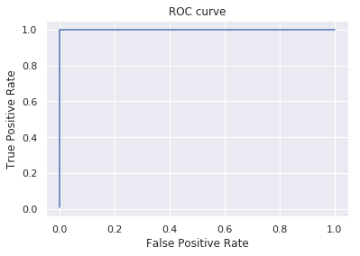

```python
plt.plot(fpr, tpr)
plt.title("ROC curve")
plt.xlabel("False Positive Rate")
plt.ylabel("True Positive Rate")
plt.show()
```

```python
auc(fpr, tpr)
```

```
1.0
```